# Machine Learning R

Victor Carrasco

23/10/2020

*Usando la base de datos wine (disponible en el paquete rattle.data) contiene información de 178 vinos y se clasifican en 3 tipos de vino (Type=1,2,3) a partir de 13 variables disponibles.*

#### primero hay que cargar datos y convertir en factor la variable “Type” ya que es la variable target:

```r
library(rattle.data)
data(wine)

wine$Type <- as.factor(wine$Type)

wine_original <-wine
```

Explorando la base de datos

```r
head(wine)
```

```
##   Type Alcohol Malic  Ash Alcalinity Magnesium Phenols Flavanoids Nonflavanoids
## 1    1   14.23  1.71 2.43       15.6       127    2.80       3.06          0.28
## 2    1   13.20  1.78 2.14       11.2       100    2.65       2.76          0.26
## 3    1   13.16  2.36 2.67       18.6       101    2.80       3.24          0.30
## 4    1   14.37  1.95 2.50       16.8       113    3.85       3.49          0.24
## 5    1   13.24  2.59 2.87       21.0       118    2.80       2.69          0.39
## 6    1   14.20  1.76 2.45       15.2       112    3.27       3.39          0.34
##   Proanthocyanins Color  Hue Dilution Proline
## 1            2.29  5.64 1.04     3.92    1065
## 2            1.28  4.38 1.05     3.40    1050
## 3            2.81  5.68 1.03     3.17    1185
## 4            2.18  7.80 0.86     3.45    1480
## 5            1.82  4.32 1.04     2.93     735
## 6            1.97  6.75 1.05     2.85    1450
```

```r
table(wine$Type)
```

```
##
##  1  2  3
## 59 71 48
```

#### antes de proceder a utilziar un mecanismo de ML, es conveniente estandarizar variables. Pueden hacerse de 2 maneras, normalizando o desviacion estandar. Utilizo el primero

```r
normalizar_variables <- function(x)
{
  return((x- min(x)) /(max(x)-min(x)))
}


wine[,-1] <- as.data.frame(lapply(wine[,-1],normalizar_variables))
```

#### separamos la base de datos en 70% para entrenamiento y 30% para prueba.

Para hacer esta separación siempre replicable, lo mejor es usar una semilla.

```r
set.seed(2020)



position <- sample(1:nrow(wine), 0.7*nrow(wine))

# tomo una muestra aleatoria de la base de datos y uso el 70% (sample y 0.7)

training <- wine[position, ]

# determinada la muestra anterior la uso de base de entrenamiento

test <- wine[-position, ]

# y el resto de la base 30%  para prueba
```

#### utilizamos 3 tipos de algortimos Random Forest (20 árboles y 4 variables) y Support Vector Machine (kernel radial) y KNN(k=7).

$Random Forest$

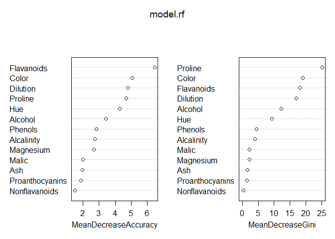

```r
require(randomForest)


# n. tree = 20, reemplazo  si, importancia de cada variable
# mtry=4
model.rf <- randomForest(Type ~ ., data=wine,
                       ntree=20, mtry=4, replace=TRUE, importance=T)

varImpPlot(model.rf)
```

Con esto es posible determinar la importancia según 2 tipos de criterios, de precisión y Gini, por convención utilizaremos este ultimo.

Según el criterio de Gini, la variable Proline es la que se repite más veces en los arboles, esto viene seguido de Color y Flavanoids.

$Support Vector Machine$

```r
require(e1071)
model.svm <- svm(Type ~ ., data=training,
               kernel="radial")
```

$k-Nearest Neighbors$

```r
require(class)
modelo_KNN <- knn(train=training[,-1], test=training[,-1], cl=training[,1], k=7)
```

#### el porcentaje de clasificaciones correctas utilizando la base de entrenamiento podemos calcularlo como:

$Random Forest$

tenemos para Random Forest que la calidad de ajuste viene dada por:

```r
# Valores predictivos
predval.rf1 <- predict(model.rf, training)


# Matriz de confusión
table(training$Type, predval.rf1)
```

```
##    predval.rf1
##      1  2  3
##   1 45  0  0
##   2  0 44  0
##   3  0  0 35
```

- Se clasifico correctamente 45 vinos de tipo 1
- Se clasifico correctamente 44 vinos de tipo 2
- Se clasifico correctamente 35 vinos de tipo 3

Porcentaje de clasificación correcta

```r
mean(training$Type == predval.rf1)
```

```
## [1] 1
```

Para random forest se ha obtenido un 100% de ajuste en la base de entrenamiento, lo cual podria ser indicio de un sobre ajuste, para determinar de mejor manera esto, es conveniente realizar una validación cruzada.

$Support Vector Machine$

tenemos para Support Vector Machine la calidad de ajuste viene dada por:

```r
# Valores predictivos
predval.svm <- predict(model.svm, training)

# Matriz de confusión
table(training$Type, predval.svm)
```

```
##    predval.svm
##      1  2  3
##   1 45  0  0
##   2  0 44  0
##   3  0  0 35
```

- Se clasifico correctamente 45 vinos de tipo 1
- Se clasifico correctamente 44 vinos de tipo 2
- Se clasifico correctamente 35 vinos de tipo 3

Porcentaje de clasificación correcta

```r
mean(training$Type == predval.svm)
```

```
## [1] 1
```

$k-Nearest Neighbors$

tenemos para KNN la calidad de ajuste viene dada por:

```r
# Matriz de confusión
table(training$Type, modelo_KNN)
```

```
##    modelo_KNN
##      1  2  3
##   1 45  0  0
##   2  1 41  2
##   3  0  0 35
```

- Se clasifico correctamente 45 vinos de tipo 1
- Se clasifico correctamente 41 vinos de tipo 2
- Se clasifico correctamente 35 vinos de tipo 3

Porcentaje de clasificación correcta

```r
mean(training$Type == modelo_KNN)
```

```
## [1] 0.9758065
```

#### Aplicando una validación cruzada

Metodo cross validation, 30 iteraciones,

70% para la base de entrenamiento 30% prueba

$Random Forest$

la validación cruzada para Random Forest viene dada por:

```r
library(caret)



( cv_rf <- train(Type ~., data=training, method="rf",
               trControl=trainControl(method="cv", number=30, p=0.7),
               tuneGrid=expand.grid(.mtry=4)) )
```

```
## Random Forest
##
## 124 samples
##  13 predictor
##   3 classes: '1', '2', '3'
##
## No pre-processing
## Resampling: Cross-Validated (30 fold)
## Summary of sample sizes: 120, 120, 121, 119, 121, 121, ...
## Resampling results:
##
##   Accuracy   Kappa
##   0.9933333  0.9901961
##
## Tuning parameter 'mtry' was held constant at a value of 4
```

$Support Vector Machine$

la validación cruzada para Support Vector Machine viene dada por:

```r
(cv.svm <- train(Type ~., data=training, method="svmRadial",
                 trControl=trainControl(method="cv", number=30, p=0.7)))
```

```
## Support Vector Machines with Radial Basis Function Kernel
##
## 124 samples
##  13 predictor
##   3 classes: '1', '2', '3'
##
## No pre-processing
## Resampling: Cross-Validated (30 fold)
## Summary of sample sizes: 119, 120, 120, 120, 121, 119, ...
## Resampling results across tuning parameters:
##
##   C     Accuracy   Kappa
##   0.25  0.9777778  0.9666667
##   0.50  0.9777778  0.9666667
##   1.00  0.9888889  0.9833333
##
## Tuning parameter 'sigma' was held constant at a value of 0.068997
## Accuracy was used to select the optimal model using the largest value.
## The final values used for the model were sigma = 0.068997 and C = 1.
```

$k-Nearest Neighbors$

la validación cruzada para KNN viene dada por:

```r
( cv_KNN <- train(Type ~., data=training, method="knn",
                  trControl=trainControl(method="cv", number=30, p=0.7)))
```

```
## k-Nearest Neighbors
##
## 124 samples
##  13 predictor
##   3 classes: '1', '2', '3'
##
## No pre-processing
## Resampling: Cross-Validated (30 fold)
## Summary of sample sizes: 119, 120, 121, 120, 120, 120, ...
## Resampling results across tuning parameters:
##
##   k  Accuracy   Kappa
##   5  0.9627778  0.9441919
##   7  0.9711111  0.9563131
##   9  0.9777778  0.9674242
##
## Accuracy was used to select the optimal model using the largest value.
## The final value used for the model was k = 9.
```

#### (vi) [0.5 pt] Aplicando estos modelos ajustados a la base de prueba

$Random Forest$

Validacion para Random Forest utilizando la base de prueba.

```r
# Valores predictivos
predval.rf2 <- predict(model.rf, test)

# Matriz de confusión
table(test$Type, predval.rf2)
```

```
##    predval.rf2
##      1  2  3
##   1 14  0  0
##   2  0 27  0
##   3  0  0 13
```

- Se clasifico correctamente 14 vinos de tipo 1
- Se clasifico correctamente 27 vinos de tipo 2
- Se clasifico correctamente 13 vinos de tipo 3

Porcentaje de clasificación correcta:

```r
mean(test$Type == predval.rf2)
```

```
## [1] 1
```

Donde existe una clasificación correcta para Random Forest del 100% de los vinos según su tipo.

$Support Vector Machine$

Validacion para Support Vector Machine utilizando la base de prueba.

```r
# Valores predictivos
predval.svm <- predict(model.svm, test)

# Matriz de confusión
table(test$Type, predval.svm)
```

```
##    predval.svm
##      1  2  3
##   1 14  0  0
##   2  0 26  1
##   3  0  0 13
```

Porcentaje de clasificación correcta:

```r
mean(test$Type == predval.svm)
```

```
## [1] 0.9814815
```

Donde existe una clasificación correcta para Support Vector Machine del 98.1% de los vinos según su tipo.

$k-Nearest Neighbors$

Validacion para KNN utilizando la base de prueba.

```r
modelo_KNN_test <- knn(train=test[,-1], test=test[,-1], cl=test[,1], k=7)

# Matriz de confusión
table(test$Type, modelo_KNN_test)
```

```
##    modelo_KNN_test
##      1  2  3
##   1 14  0  0
##   2  1 25  1
##   3  0  1 12
```

- Se clasifico correctamente 14 vinos de tipo 1
- Se clasifico correctamente 25 vinos de tipo 2
- Se clasifico correctamente 12 vinos de tipo 3

Porcentaje de clasificación correcta:

```r
mean(test$Type == modelo_KNN_test)
```

```
## [1] 0.9444444
```

Donde existe una clasificación correcta para KNN del 94.4% de los vinos según su tipo.